Challenge 1- Text Analysis

Let’s load the packages before moving on to import the data: In this challenge, the content of our learning journals will be analysed over time and Text analysis will be performed on it. The learning journal contains a weekly personal report / summary of the weekly lectures of the seminar(Data to Evidence).

```r
library(tidyverse)
library(here)
library(tm)
library(dplyr)
library(wordcloud)
library(tidytext)
library(dataedu)
library(ggplot2)
```

## Import Data

Let’s start by getting the data into our environment so we can start analyzing it. The contents of the journal were copied and saved in .txt files. So a simple readLines() operation on the .txt files will be sufficient in writing out the content contained in the files.

After that, the content written out will be saved in Data frames.

```r
file_path1 <- "week1.txt"
file_path2 <- "week2.txt"
file_path3 <- "week3.txt"
file_path4 <- "week4.txt"
file_path5 <- "week5.txt"
file_path6 <- "week6.txt"

text_lines1 <- readLines(file_path1, warn = FALSE)
text_lines2 <- readLines(file_path2, warn = FALSE)
text_lines3 <- readLines(file_path3, warn = FALSE)
text_lines4 <- readLines(file_path4, warn = FALSE)
text_lines5 <- readLines(file_path5, warn = FALSE)
text_lines6 <- readLines(file_path6, warn = FALSE)

week1_df <- data.frame(Content = text_lines1)
week2_df <- data.frame(Content = text_lines2)
week3_df <- data.frame(Content = text_lines3)
week4_df <- data.frame(Content = text_lines4)
week5_df <- data.frame(Content = text_lines5)
week6_df <- data.frame(Content = text_lines6)
```

# Tokenization

```r
week1Tokens <-
  week1_df %>%
  unnest_tokens(output = word, input = Content)

week2Tokens <-
  week2_df %>%
  unnest_tokens(output = word, input = Content)

week3Tokens <-
  week3_df %>%
  unnest_tokens(output = word, input = Content)

week4Tokens <-
  week4_df %>%
  unnest_tokens(output = word, input = Content)

week5Tokens <-
  week5_df %>%
  unnest_tokens(output = word, input = Content)

week6Tokens <-
  week6_df %>%
  unnest_tokens(output = word, input = Content)
```

Stop word removal

In this step meaningless word that add no meaning to the main context of the sentences will be removed. The stop word list is already predefined by another package.

```r
data(stop_words)

week1Tokens <-
  week1Tokens %>%
  anti_join(stop_words, by = "word")

week2Tokens <-
  week2Tokens %>%
  anti_join(stop_words, by = "word")

week3Tokens <-
  week3Tokens %>%
  anti_join(stop_words, by = "word")

week4Tokens <-
  week4Tokens %>%
  anti_join(stop_words, by = "word")

week5Tokens <-
  week5Tokens %>%
  anti_join(stop_words, by = "word")

week6Tokens <-
  week6Tokens %>%
  anti_join(stop_words, by = "word")
```

#join all tokens

The resulting tokens will be joined using the bind_rows operation.

```r
combined_tokens <- bind_rows(week1Tokens, week2Tokens, week3Tokens, week4Tokens, week5Tokens, week6Tokens)
```

Visualization

A function will be created for this(create_word_cloud).

# Question

On a weekly basis, what were the most occurring words?

[figure not shown]

[figure not shown]

[figure not shown]

[figure not shown]

[figure not shown]

[figure not shown]

```r
create_word_cloud <- function(tokens){
  wordcloud(words = week1Tokens, min.freq = 1, scale = c(3, 0.5), colors = brewer.pal(8, "Dark2"))

}

word_cloud <- lapply(paste0("week",1:6,"Tokens"), create_word_cloud)
```

Below is a summary of frequently used words in the journal.

```r
combined_tokens %>%
    count(word, sort = TRUE)
```

```
##                     word  n
## 1                   data 58
## 2                dataset 19
## 3               analysis 14
## 4                chapter 13
## 5               includes  9
## 6            educational  7
## 7              gradebook  7
## 8             introduced  7
## 9              functions  6
## 10                 model  6
## 11            operations  6
## 12                  plot  6
## 13          relationship  6
## 14                report  6
```

[output cut: 394 more lines]

```r
most_occuring <- combined_tokens %>%


  count(word, sort = TRUE) %>%
  # n as a percent of total words
  mutate(percent = n / sum(n) * 100)
```

# sentiment Analysis

This adds emotional context to the analysis. There is an already defined Dataset (nrc) from a package as seen below using the function get_sentiments. Sentiments could be negative, positive, neutral etc.

```r
get_sentiments("nrc")
```

```
## # A tibble: 13,872 × 2
##    word        sentiment
##    <chr>       <chr>
##  1 abacus      trust
##  2 abandon     fear
##  3 abandon     negative
##  4 abandon     sadness
##  5 abandoned   anger
##  6 abandoned   fear
##  7 abandoned   negative
##  8 abandoned   sadness
##  9 abandonment anger
## 10 abandonment fear
## # ℹ 13,862 more rows
```

# count positive words

Below the count of the words associated with positive sentiments is shown in a table.

```r
# Only positive in the NRC dataset
nrc_pos <-
  get_sentiments("nrc") %>%
  filter(sentiment == "positive")

# Match to tokens
pos_tokens_count <-
  combined_tokens %>%
  inner_join(nrc_pos, by = "word") %>%
  # Total appearance of positive words
  count(word, sort = TRUE)

pos_tokens_count
```

```
##             word n
## 1    educational 7
## 2          model 6
## 3       learning 5
## 4      formative 4
## 5            fun 4
## 6       cleaning 3
## 7      knowledge 3
## 8     vocabulary 3
## 9          count 2
## 10      included 2
## 11         level 2
## 12         score 2
## 13         child 1
## 14         clean 1
```

[output cut: 28 more lines]

# Question

What words are associated with positivity and their frequencies?

Below is a sorted bar chart showing the counts of words associated with Positivity.

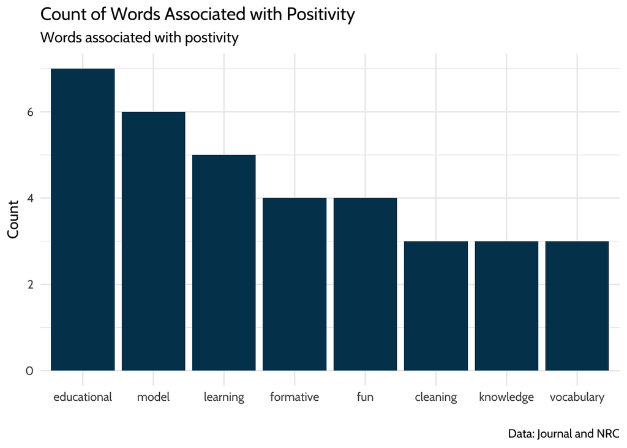

```r
pos_tokens_count %>%
  # only words that appear 75 times or more
  filter(n >= 3) %>%
  ggplot(., aes(x = reorder(word, -n), y = n)) +
  geom_bar(stat = "identity", fill = dataedu_colors("darkblue")) +
  labs(
    title = "Count of Words Associated with Positivity",
    subtitle = "Words associated with postivity",
    caption = "Data: Journal and NRC",
    x = "",
    y = "Count"
  ) +
  theme_dataedu()
```

# Other Visualization

Using another approach, the contents of the journal will be extracted, pre processed and visualized. Firstly, the data is read this time using a function read_and_preprocess.

# Question

Which week of the lecture was the student more happy?

```r
read_and_preprocess <- function(file_path) {
  text <- tolower(readLines(file_path, warn = FALSE))
  text <- gsub("[[:punct:]]", " ", text)
  return(text)
}

texts <- lapply(paste0("week", 1:6, ".txt"), read_and_preprocess)
```

```r
positive_words <- get_sentiments("afinn")$word

# Function to count positive words in a text
count_positive_words <- function(text) {
  words <- unlist(strsplit(text, " "))
  positive_count <- sum(words %in% positive_words)
  return(positive_count)
}

positive_counts <- sapply(texts, count_positive_words)
```

```r
weeks <- paste0("Week", 1:6)
df2 <- data.frame(Week = weeks, PositiveWordsCount = positive_counts)
```

```
## `geom_line()`: Each group consists of only one observation.
## ℹ Do you need to adjust the group aesthetic?
```

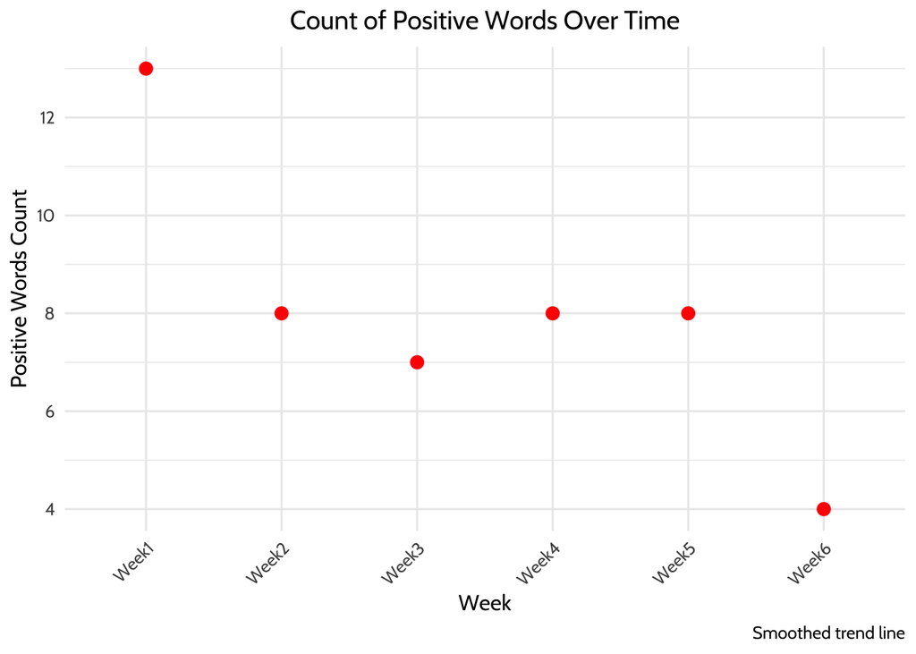

```r
ggplot(df2, aes(x = Week, y = PositiveWordsCount)) +
  geom_line(color = "blue",size = 2) +
  geom_point(color = "red", size = 3) +
  geom_smooth(method = "loess", se = FALSE, color = "green") +
  labs(
    title = "Count of Positive Words Over Time",
    x = "Week",
    y = "Positive Words Count",
    caption = "Smoothed trend line"
  ) +
  theme_dataedu() +
  theme(
    plot.title = element_text(hjust = 0.5),
    axis.title = element_text(face = "bold"),
    axis.text.x = element_text(angle = 45, hjust = 1)
  )
```